# Risk Factor Analysis

## Outcome Variable

**Outcome Variable:** pers_wasted624

## Predictor Variables

**Intervention Variable:** ever_swasted06

**Adjustment Set:**

unadjusted

## Stratifying Variables

The analysis was stratified on these variable(s):

- studyid
- country

## Data Summary

| studyid | country | ever_swasted06 | pers_wasted624 | n_cell | n | outcome_variable |
| --- | --- | --- | --- | --- | --- | --- |
| CMC-V-BCS-2002 | INDIA | 0 | 0 | 287 | 370 | pers_wasted624 |
| CMC-V-BCS-2002 | INDIA | 0 | 1 | 14 | 370 | pers_wasted624 |
| CMC-V-BCS-2002 | INDIA | 1 | 0 | 55 | 370 | pers_wasted624 |
| CMC-V-BCS-2002 | INDIA | 1 | 1 | 14 | 370 | pers_wasted624 |
| CMIN | BANGLADESH | 0 | 0 | 221 | 252 | pers_wasted624 |
| CMIN | BANGLADESH | 0 | 1 | 20 | 252 | pers_wasted624 |
| CMIN | BANGLADESH | 1 | 0 | 6 | 252 | pers_wasted624 |
| CMIN | BANGLADESH | 1 | 1 | 5 | 252 | pers_wasted624 |
| COHORTS | GUATEMALA | 0 | 0 | 914 | 1017 | pers_wasted624 |
| COHORTS | GUATEMALA | 0 | 1 | 37 | 1017 | pers_wasted624 |
| COHORTS | GUATEMALA | 1 | 0 | 62 | 1017 | pers_wasted624 |
| COHORTS | GUATEMALA | 1 | 1 | 4 | 1017 | pers_wasted624 |
| COHORTS | INDIA | 0 | 0 | 5796 | 6892 | pers_wasted624 |
| COHORTS | INDIA | 0 | 1 | 488 | 6892 | pers_wasted624 |
| COHORTS | INDIA | 1 | 0 | 326 | 6892 | pers_wasted624 |
| COHORTS | INDIA | 1 | 1 | 282 | 6892 | pers_wasted624 |
| COHORTS | PHILIPPINES | 0 | 0 | 2431 | 2808 | pers_wasted624 |
| COHORTS | PHILIPPINES | 0 | 1 | 175 | 2808 | pers_wasted624 |
| COHORTS | PHILIPPINES | 1 | 0 | 151 | 2808 | pers_wasted624 |
| COHORTS | PHILIPPINES | 1 | 1 | 51 | 2808 | pers_wasted624 |
| CONTENT | PERU | 0 | 0 | 214 | 215 | pers_wasted624 |
| CONTENT | PERU | 0 | 1 | 0 | 215 | pers_wasted624 |
| CONTENT | PERU | 1 | 0 | 1 | 215 | pers_wasted624 |
| CONTENT | PERU | 1 | 1 | 0 | 215 | pers_wasted624 |
| EE | PAKISTAN | 0 | 0 | 298 | 374 | pers_wasted624 |
| EE | PAKISTAN | 0 | 1 | 37 | 374 | pers_wasted624 |
| EE | PAKISTAN | 1 | 0 | 27 | 374 | pers_wasted624 |
| EE | PAKISTAN | 1 | 1 | 12 | 374 | pers_wasted624 |
| GMS-Nepal | NEPAL | 0 | 0 | 433 | 590 | pers_wasted624 |
| GMS-Nepal | NEPAL | 0 | 1 | 83 | 590 | pers_wasted624 |

[output cut: 90 more lines]

The following strata were considered:

- studyid: CMC-V-BCS-2002, country: INDIA
- studyid: CMIN, country: BANGLADESH
- studyid: COHORTS, country: GUATEMALA
- studyid: COHORTS, country: INDIA
- studyid: COHORTS, country: PHILIPPINES
- studyid: CONTENT, country: PERU
- studyid: EE, country: PAKISTAN
- studyid: GMS-Nepal, country: NEPAL
- studyid: Guatemala BSC, country: GUATEMALA
- studyid: IRC, country: INDIA
- studyid: JiVitA-3, country: BANGLADESH
- studyid: JiVitA-4, country: BANGLADESH
- studyid: Keneba, country: GAMBIA
- studyid: LCNI-5, country: MALAWI
- studyid: MAL-ED, country: BANGLADESH
- studyid: MAL-ED, country: BRAZIL
- studyid: MAL-ED, country: INDIA
- studyid: MAL-ED, country: NEPAL
- studyid: MAL-ED, country: PERU
- studyid: MAL-ED, country: SOUTH AFRICA
- studyid: MAL-ED, country: TANZANIA, UNITED REPUBLIC OF
- studyid: NIH-Birth, country: BANGLADESH
- studyid: NIH-Crypto, country: BANGLADESH
- studyid: PROBIT, country: BELARUS
- studyid: PROVIDE, country: BANGLADESH
- studyid: ResPak, country: PAKISTAN
- studyid: SAS-CompFeed, country: INDIA
- studyid: SAS-FoodSuppl, country: INDIA
- studyid: TanzaniaChild2, country: TANZANIA, UNITED REPUBLIC OF
- studyid: ZVITAMBO, country: ZIMBABWE

### Dropped Strata

Some strata were dropped due to rare outcomes:

- studyid: COHORTS, country: GUATEMALA
- studyid: CONTENT, country: PERU
- studyid: Guatemala BSC, country: GUATEMALA
- studyid: LCNI-5, country: MALAWI
- studyid: MAL-ED, country: BANGLADESH
- studyid: MAL-ED, country: BRAZIL
- studyid: MAL-ED, country: NEPAL
- studyid: MAL-ED, country: PERU
- studyid: MAL-ED, country: SOUTH AFRICA
- studyid: MAL-ED, country: TANZANIA, UNITED REPUBLIC OF

## Methods Detail

We’re interested in the causal parameters $E[Y_a]$ for all values of $a \in \mathcal{A}$. These parameters represent the mean outcome if, possibly contrary to fact, we intervened to set all units to have $A=a$. Under the randomization and positivity assumptions, these are identified by the statistical parameters $\psi_a=E_W[E_{Y|A,W}(Y|A=a,W)]$. In addition, we’re interested in the mean of $Y$, $E[Y]$ under no intervention (the observed mean). We will estimate these parameters by using SuperLearner to fit the relevant likelihood factors – $E_{Y|A,W}(Y|A=a,W)$ and $p(A=a|W)$, and then updating our likelihood fit using a joint TMLE.

For unadjusted analyses ($W=\{\}$), initial likelihoods were estimated using Lrnr_glm to estimate the simple $E(Y|A)$ and Lrnr_mean to estimate $p(A)$. For adjusted analyses, a small library containing Lrnr_glmnet, Lrnr_xgboost, and Lrnr_mean was used.

Having estimated these parameters, we will then use the delta method to estimate relative risks and attributable risks relative to a prespecified baseline level of $A$.

# Results Detail

## Results Plots

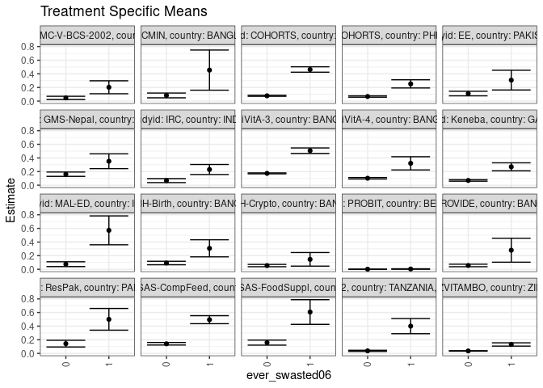

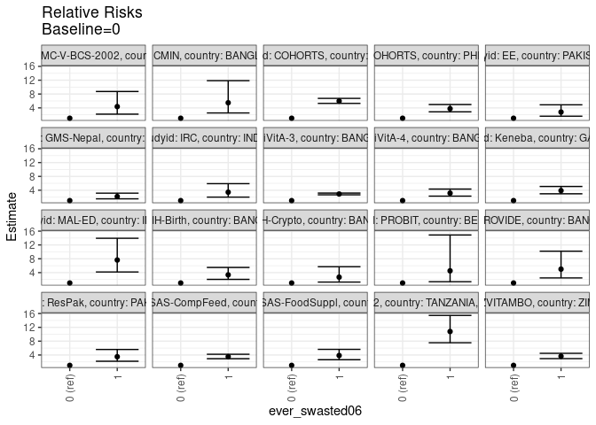

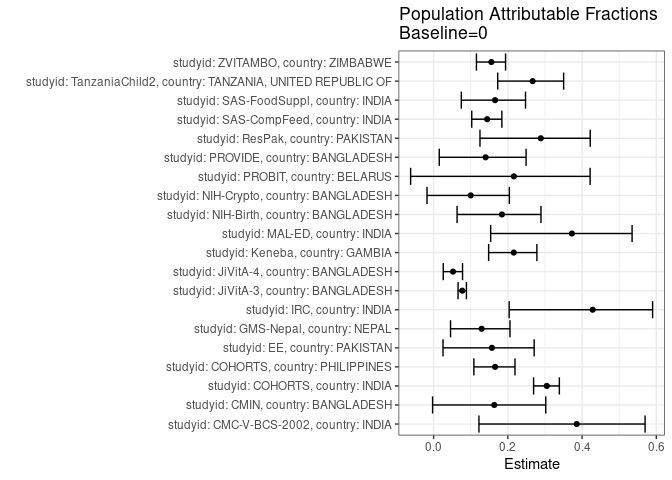

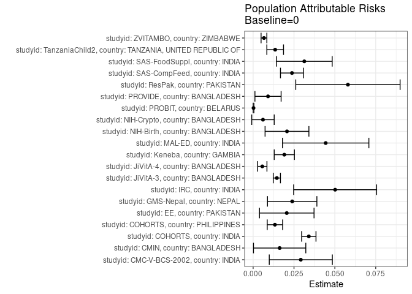

## Results Table

### Parameter: TSM

| studyid | country | intervention_level | baseline_level | estimate | ci_lower | ci_upper |
| --- | --- | --- | --- | --- | --- | --- |
| CMC-V-BCS-2002 | INDIA | 0 | NA | 0.0465116 | 0.0226889 | 0.0703343 |
| CMC-V-BCS-2002 | INDIA | 1 | NA | 0.2028986 | 0.1078802 | 0.2979169 |
| CMIN | BANGLADESH | 0 | NA | 0.0829876 | 0.0480898 | 0.1178853 |
| CMIN | BANGLADESH | 1 | NA | 0.4545455 | 0.1597077 | 0.7493832 |
| COHORTS | INDIA | 0 | NA | 0.0776575 | 0.0710400 | 0.0842751 |
| COHORTS | INDIA | 1 | NA | 0.4638158 | 0.4241736 | 0.5034580 |
| COHORTS | PHILIPPINES | 0 | NA | 0.0671527 | 0.0575416 | 0.0767639 |
| COHORTS | PHILIPPINES | 1 | NA | 0.2524752 | 0.1925552 | 0.3123953 |
| EE | PAKISTAN | 0 | NA | 0.1104478 | 0.0768375 | 0.1440580 |
| EE | PAKISTAN | 1 | NA | 0.3076923 | 0.1626465 | 0.4527381 |
| GMS-Nepal | NEPAL | 0 | NA | 0.1608527 | 0.1291260 | 0.1925794 |
| GMS-Nepal | NEPAL | 1 | NA | 0.3513514 | 0.2424894 | 0.4602133 |
| IRC | INDIA | 0 | NA | 0.0669014 | 0.0378076 | 0.0959952 |
| IRC | INDIA | 1 | NA | 0.2301587 | 0.1565707 | 0.3037468 |
| JiVitA-3 | BANGLADESH | 0 | NA | 0.1735022 | 0.1672191 | 0.1797852 |
| JiVitA-3 | BANGLADESH | 1 | NA | 0.5059761 | 0.4654853 | 0.5464668 |
| JiVitA-4 | BANGLADESH | 0 | NA | 0.1016650 | 0.0913042 | 0.1120259 |
| JiVitA-4 | BANGLADESH | 1 | NA | 0.3208955 | 0.2239934 | 0.4177976 |
| Keneba | GAMBIA | 0 | NA | 0.0692641 | 0.0583476 | 0.0801805 |
| Keneba | GAMBIA | 1 | NA | 0.2694064 | 0.2106355 | 0.3281773 |
| MAL-ED | INDIA | 0 | NA | 0.0747664 | 0.0394524 | 0.1100803 |
| MAL-ED | INDIA | 1 | NA | 0.5714286 | 0.3593206 | 0.7835366 |
| NIH-Birth | BANGLADESH | 0 | NA | 0.0918367 | 0.0662426 | 0.1174309 |
| NIH-Birth | BANGLADESH | 1 | NA | 0.3076923 | 0.1821311 | 0.4332535 |
| NIH-Crypto | BANGLADESH | 0 | NA | 0.0542522 | 0.0372404 | 0.0712640 |
| NIH-Crypto | BANGLADESH | 1 | NA | 0.1458333 | 0.0459197 | 0.2457470 |
| PROBIT | BELARUS | 0 | NA | 0.0008500 | 0.0002192 | 0.0014809 |
| PROBIT | BELARUS | 1 | NA | 0.0038402 | 0.0006414 | 0.0070391 |
| PROVIDE | BANGLADESH | 0 | NA | 0.0559322 | 0.0373752 | 0.0744892 |
| PROVIDE | BANGLADESH | 1 | NA | 0.2800000 | 0.1038524 | 0.4561476 |
| ResPak | PAKISTAN | 0 | NA | 0.1428571 | 0.0937632 | 0.1919511 |
| ResPak | PAKISTAN | 1 | NA | 0.5000000 | 0.3406851 | 0.6593149 |
| SAS-CompFeed | INDIA | 0 | NA | 0.1409760 | 0.1223961 | 0.1595559 |
| SAS-CompFeed | INDIA | 1 | NA | 0.4946237 | 0.4358492 | 0.5533981 |
| SAS-FoodSuppl | INDIA | 0 | NA | 0.1577540 | 0.1207658 | 0.1947422 |
| SAS-FoodSuppl | INDIA | 1 | NA | 0.6071429 | 0.4260202 | 0.7882655 |
| TanzaniaChild2 | TANZANIA, UNITED REPUBLIC OF | 0 | NA | 0.0370561 | 0.0286547 | 0.0454575 |
| TanzaniaChild2 | TANZANIA, UNITED REPUBLIC OF | 1 | NA | 0.4000000 | 0.2891002 | 0.5108998 |
| ZVITAMBO | ZIMBABWE | 0 | NA | 0.0359647 | 0.0323118 | 0.0396177 |
| ZVITAMBO | ZIMBABWE | 1 | NA | 0.1308411 | 0.1066893 | 0.1549929 |

### Parameter: E(Y)

| studyid | country | intervention_level | baseline_level | estimate | ci_lower | ci_upper |
| --- | --- | --- | --- | --- | --- | --- |
| CMC-V-BCS-2002 | INDIA | NA | NA | 0.0756757 | 0.0486905 | 0.1026609 |
| CMIN | BANGLADESH | NA | NA | 0.0992063 | 0.0622241 | 0.1361886 |
| COHORTS | INDIA | NA | NA | 0.1117237 | 0.1042858 | 0.1191617 |
| COHORTS | PHILIPPINES | NA | NA | 0.0804843 | 0.0704205 | 0.0905481 |
| EE | PAKISTAN | NA | NA | 0.1310160 | 0.0967738 | 0.1652583 |
| GMS-Nepal | NEPAL | NA | NA | 0.1847458 | 0.1534039 | 0.2160876 |
| IRC | INDIA | NA | NA | 0.1170732 | 0.0859146 | 0.1482317 |
| JiVitA-3 | BANGLADESH | NA | NA | 0.1880070 | 0.1814627 | 0.1945512 |
| JiVitA-4 | BANGLADESH | NA | NA | 0.1072724 | 0.0967392 | 0.1178055 |
| Keneba | GAMBIA | NA | NA | 0.0883377 | 0.0767324 | 0.0999430 |
| MAL-ED | INDIA | NA | NA | 0.1191489 | 0.0776405 | 0.1606574 |
| NIH-Birth | BANGLADESH | NA | NA | 0.1125461 | 0.0859151 | 0.1391771 |
| NIH-Crypto | BANGLADESH | NA | NA | 0.0602740 | 0.0429977 | 0.0775502 |
| PROBIT | BELARUS | NA | NA | 0.0010846 | 0.0004977 | 0.0016715 |
| PROVIDE | BANGLADESH | NA | NA | 0.0650407 | 0.0455353 | 0.0845460 |
| ResPak | PAKISTAN | NA | NA | 0.2008547 | 0.1494120 | 0.2522974 |
| SAS-CompFeed | INDIA | NA | NA | 0.1647399 | 0.1451050 | 0.1843747 |
| SAS-FoodSuppl | INDIA | NA | NA | 0.1890547 | 0.1507312 | 0.2273783 |
| TanzaniaChild2 | TANZANIA, UNITED REPUBLIC OF | NA | NA | 0.0505451 | 0.0409848 | 0.0601054 |
| ZVITAMBO | ZIMBABWE | NA | NA | 0.0425869 | 0.0387663 | 0.0464075 |

### Parameter: RR

| studyid | country | intervention_level | baseline_level | estimate | ci_lower | ci_upper |
| --- | --- | --- | --- | --- | --- | --- |
| CMC-V-BCS-2002 | INDIA | 0 | 0 | 1.000000 | 1.000000 | 1.000000 |
| CMC-V-BCS-2002 | INDIA | 1 | 0 | 4.362319 | 2.179285 | 8.732144 |
| CMIN | BANGLADESH | 0 | 0 | 1.000000 | 1.000000 | 1.000000 |
| CMIN | BANGLADESH | 1 | 0 | 5.477273 | 2.528380 | 11.865507 |
| COHORTS | INDIA | 0 | 0 | 1.000000 | 1.000000 | 1.000000 |
| COHORTS | INDIA | 1 | 0 | 5.972579 | 5.293536 | 6.738728 |
| COHORTS | PHILIPPINES | 0 | 0 | 1.000000 | 1.000000 | 1.000000 |
| COHORTS | PHILIPPINES | 1 | 0 | 3.759717 | 2.849654 | 4.960418 |
| EE | PAKISTAN | 0 | 0 | 1.000000 | 1.000000 | 1.000000 |
| EE | PAKISTAN | 1 | 0 | 2.785863 | 1.589579 | 4.882446 |
| GMS-Nepal | NEPAL | 0 | 0 | 1.000000 | 1.000000 | 1.000000 |
| GMS-Nepal | NEPAL | 1 | 0 | 2.184305 | 1.512866 | 3.153742 |
| IRC | INDIA | 0 | 0 | 1.000000 | 1.000000 | 1.000000 |
| IRC | INDIA | 1 | 0 | 3.440267 | 2.005288 | 5.902116 |
| JiVitA-3 | BANGLADESH | 0 | 0 | 1.000000 | 1.000000 | 1.000000 |
| JiVitA-3 | BANGLADESH | 1 | 0 | 2.916253 | 2.674648 | 3.179682 |
| JiVitA-4 | BANGLADESH | 0 | 0 | 1.000000 | 1.000000 | 1.000000 |
| JiVitA-4 | BANGLADESH | 1 | 0 | 3.156400 | 2.297882 | 4.335671 |
| Keneba | GAMBIA | 0 | 0 | 1.000000 | 1.000000 | 1.000000 |
| Keneba | GAMBIA | 1 | 0 | 3.889555 | 2.971801 | 5.090730 |
| MAL-ED | INDIA | 0 | 0 | 1.000000 | 1.000000 | 1.000000 |
| MAL-ED | INDIA | 1 | 0 | 7.642857 | 4.191447 | 13.936300 |
| NIH-Birth | BANGLADESH | 0 | 0 | 1.000000 | 1.000000 | 1.000000 |
| NIH-Birth | BANGLADESH | 1 | 0 | 3.350427 | 2.044040 | 5.491752 |
| NIH-Crypto | BANGLADESH | 0 | 0 | 1.000000 | 1.000000 | 1.000000 |
| NIH-Crypto | BANGLADESH | 1 | 0 | 2.688063 | 1.265352 | 5.710413 |
| PROBIT | BELARUS | 0 | 0 | 1.000000 | 1.000000 | 1.000000 |
| PROBIT | BELARUS | 1 | 0 | 4.517901 | 1.371594 | 14.881545 |
| PROVIDE | BANGLADESH | 0 | 0 | 1.000000 | 1.000000 | 1.000000 |
| PROVIDE | BANGLADESH | 1 | 0 | 5.006061 | 2.458188 | 10.194764 |
| ResPak | PAKISTAN | 0 | 0 | 1.000000 | 1.000000 | 1.000000 |
| ResPak | PAKISTAN | 1 | 0 | 3.500000 | 2.190481 | 5.592380 |
| SAS-CompFeed | INDIA | 0 | 0 | 1.000000 | 1.000000 | 1.000000 |
| SAS-CompFeed | INDIA | 1 | 0 | 3.508567 | 2.924660 | 4.209050 |
| SAS-FoodSuppl | INDIA | 0 | 0 | 1.000000 | 1.000000 | 1.000000 |
| SAS-FoodSuppl | INDIA | 1 | 0 | 3.848668 | 2.633448 | 5.624659 |
| TanzaniaChild2 | TANZANIA, UNITED REPUBLIC OF | 0 | 0 | 1.000000 | 1.000000 | 1.000000 |
| TanzaniaChild2 | TANZANIA, UNITED REPUBLIC OF | 1 | 0 | 10.794444 | 7.544996 | 15.443351 |
| ZVITAMBO | ZIMBABWE | 0 | 0 | 1.000000 | 1.000000 | 1.000000 |
| ZVITAMBO | ZIMBABWE | 1 | 0 | 3.638039 | 2.946909 | 4.491259 |

### Parameter: PAR

| studyid | country | intervention_level | baseline_level | estimate | ci_lower | ci_upper |
| --- | --- | --- | --- | --- | --- | --- |
| CMC-V-BCS-2002 | INDIA | 0 | NA | 0.0291640 | 0.0098677 | 0.0484604 |
| CMIN | BANGLADESH | 0 | NA | 0.0162188 | 0.0002139 | 0.0322237 |
| COHORTS | INDIA | 0 | NA | 0.0340662 | 0.0296779 | 0.0384545 |
| COHORTS | PHILIPPINES | 0 | NA | 0.0133316 | 0.0086203 | 0.0180429 |
| EE | PAKISTAN | 0 | NA | 0.0205683 | 0.0038806 | 0.0372559 |
| GMS-Nepal | NEPAL | 0 | NA | 0.0238930 | 0.0087859 | 0.0390002 |
| IRC | INDIA | 0 | NA | 0.0501718 | 0.0247815 | 0.0755620 |
| JiVitA-3 | BANGLADESH | 0 | NA | 0.0145048 | 0.0122998 | 0.0167098 |
| JiVitA-4 | BANGLADESH | 0 | NA | 0.0056073 | 0.0027645 | 0.0084502 |
| Keneba | GAMBIA | 0 | NA | 0.0190736 | 0.0128907 | 0.0252565 |
| MAL-ED | INDIA | 0 | NA | 0.0443826 | 0.0179485 | 0.0708166 |
| NIH-Birth | BANGLADESH | 0 | NA | 0.0207094 | 0.0072988 | 0.0341200 |
| NIH-Crypto | BANGLADESH | 0 | NA | 0.0060218 | -0.0008431 | 0.0128867 |
| PROBIT | BELARUS | 0 | NA | 0.0002346 | 0.0000115 | 0.0004577 |
| PROVIDE | BANGLADESH | 0 | NA | 0.0091084 | 0.0011028 | 0.0171141 |
| ResPak | PAKISTAN | 0 | NA | 0.0579976 | 0.0260766 | 0.0899185 |
| SAS-CompFeed | INDIA | 0 | NA | 0.0237639 | 0.0167237 | 0.0308041 |
| SAS-FoodSuppl | INDIA | 0 | NA | 0.0313007 | 0.0142375 | 0.0483639 |
| TanzaniaChild2 | TANZANIA, UNITED REPUBLIC OF | 0 | NA | 0.0134890 | 0.0083838 | 0.0185942 |
| ZVITAMBO | ZIMBABWE | 0 | NA | 0.0066222 | 0.0048570 | 0.0083874 |

### Parameter: PAF

| studyid | country | intervention_level | baseline_level | estimate | ci_lower | ci_upper |
| --- | --- | --- | --- | --- | --- | --- |
| CMC-V-BCS-2002 | INDIA | 0 | NA | 0.3853821 | 0.1220491 | 0.5697308 |
| CMIN | BANGLADESH | 0 | NA | 0.1634855 | -0.0027793 | 0.3021829 |
| COHORTS | INDIA | 0 | NA | 0.3049146 | 0.2693539 | 0.3387445 |
| COHORTS | PHILIPPINES | 0 | NA | 0.1656423 | 0.1084479 | 0.2191675 |
| EE | PAKISTAN | 0 | NA | 0.1569906 | 0.0253246 | 0.2708702 |
| GMS-Nepal | NEPAL | 0 | NA | 0.1293294 | 0.0455709 | 0.2057373 |
| IRC | INDIA | 0 | NA | 0.4285505 | 0.2035296 | 0.5899978 |
| JiVitA-3 | BANGLADESH | 0 | NA | 0.0771503 | 0.0658193 | 0.0883440 |
| JiVitA-4 | BANGLADESH | 0 | NA | 0.0522720 | 0.0259201 | 0.0779111 |
| Keneba | GAMBIA | 0 | NA | 0.2159171 | 0.1482185 | 0.2782351 |
| MAL-ED | INDIA | 0 | NA | 0.3724967 | 0.1536730 | 0.5347420 |
| NIH-Birth | BANGLADESH | 0 | NA | 0.1840080 | 0.0631875 | 0.2892463 |
| NIH-Crypto | BANGLADESH | 0 | NA | 0.0999067 | -0.0178485 | 0.2040388 |
| PROBIT | BELARUS | 0 | NA | 0.2162940 | -0.0619533 | 0.4216364 |
| PROVIDE | BANGLADESH | 0 | NA | 0.1400424 | 0.0151570 | 0.2490913 |
| ResPak | PAKISTAN | 0 | NA | 0.2887538 | 0.1248986 | 0.4219285 |
| SAS-CompFeed | INDIA | 0 | NA | 0.1442510 | 0.1027265 | 0.1838539 |
| SAS-FoodSuppl | INDIA | 0 | NA | 0.1655643 | 0.0745783 | 0.2476047 |
| TanzaniaChild2 | TANZANIA, UNITED REPUBLIC OF | 0 | NA | 0.2668705 | 0.1726780 | 0.3503390 |
| ZVITAMBO | ZIMBABWE | 0 | NA | 0.1554976 | 0.1153544 | 0.1938193 |